# Annotate Twitter images with imgrec

This short vignette demonstrates how to download and annotate images inside Tweets. Besides `imgrec`, we will use rtweet to get Twitter data and the dplyr package for data wrangling.

## Setup

Before we start, access credentials are required for Twitter and Google Cloud Vision. For this example, all credentials are stored as R environment variables. Check out the rtweet authentication vignette to obtain and use Twitter API access tokens. The authentication for Google Cloud Vision is described in the imgrec intro vignette.

```r
# load libraries
library(imgrec)
library(rtweet)
library(dplyr)

# prepare twitter credentials
app_name <- Sys.getenv('twitter_app_name')
consumer_key <-Sys.getenv('twitter_consumer_key')
consumer_secret <- Sys.getenv('twitter_consumer_secret')
access_token <- Sys.getenv('twitter_access_token')
access_token_secret <- Sys.getenv('twitter_access_secret')

# obtain twitter access token
token <- create_token(app = app_name,
             consumer_key = consumer_key,
             consumer_secret = consumer_secret,
             access_token = access_token,
             access_secret = access_token_secret,
             set_renv = TRUE)

# setup authentification for google vision
gvision_init()
```

## Download tweets

If you know the status id’s of Tweets that you would like to obtain, you can use `lookup_tweets()`, which takes a vector of status id’s as input and retrieves all corresponding tweets. URL’s of images (and videos) are stored in the list column `media_url`.

We use one of the most-retweeted tweets posted by Barack Obama as an example:

> “No one is born hating another person because of the color of his skin or his background or his religion…” ([Barack Obama, Twitter Status](https://twitter.com/BarackObama/status/896523232098078720))

```r
example <- lookup_tweets(896523232098078720)
example$media_url
```

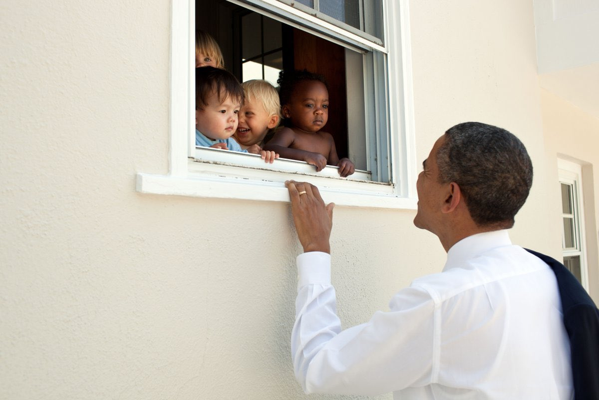

## Annotate Tweets

Now, we retrieve and parse annotations for the Tweet image:

```r
results <- get_annotations(images = example$media_url[[1]],
                           max_res = 10, # max. number of labels,
                           mode = "url", # we pass an image url
                           features = 'all') %>%
           parse_annotations()

names(results) # features obtained by Google Cloud Vision
```

[output not shown]

And that’s it! The results are stored in a list object which includes dataframes for all annotations retrieved from Google Cloud Vision:

```r
results$labels %>% head()
```

[output not shown]